# Parameter Estimation

Ivo Ugrina

September 9, 2019

## Estimating the Mean of a Normal Distribution

Let’s assume that we have a sample from the normal distribution with parameters $\mu=180$ and $\sigma=10$ and that this sample represents height of males in Split. Let’s also assume that we are given a task to estimate $\mu$, i.e. the expectation, based on samples we gather.

We have seen in the lectures that an unbiased estimor for the mean is our well known arithmetic average or mean (or sample mean). In R we can use function `mean` to calculate the average.

```r
# Reproducibility
set.seed(1337)
```

```r
# Let's take a sample from N(180, 100) of size 10.
our_sample <- rnorm(10, 180, 10)

print(our_sample)
```

```
##  [1] 181.9249 165.5330 176.7682 196.2230 173.1098 200.4212 189.4378
##  [8] 200.8193 199.1712 175.8519
```

```r
# (Arithmetic) Sample mean
mean(our_sample)
```

```
## [1] 185.926
```

To get variance we can use `var` or for standard deviation we can use `sd`.

```r
# Sample variance
var(our_sample)
```

```
## [1] 167.4676
```

```r
# Standard deviation
sd(our_sample)
```

```
## [1] 12.94093
```

```r
# Standard deviation through variance explicitly
sqrt(var(our_sample))
```

```
## [1] 12.94093
```

Since both the sample mean and sample variance are random variables (they depend on the initial sample) let’s try to depict their distribution.

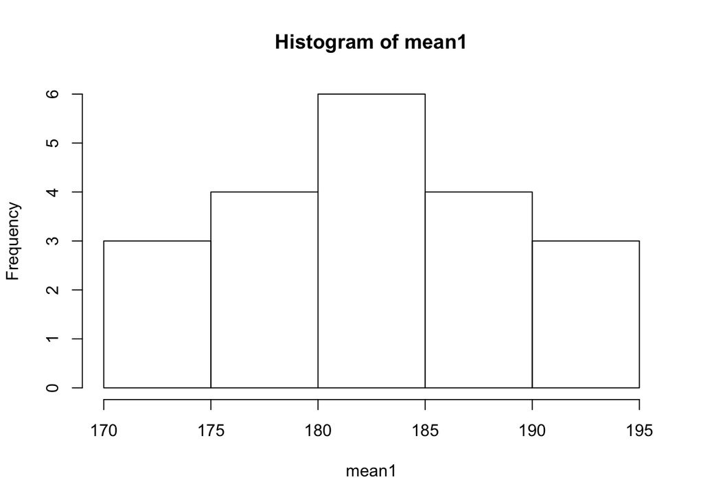

```r
mean1 <- replicate(20, mean(rnorm(3, 180, 10)))

hist(mean1)
```

The same can be achieved with the following code.

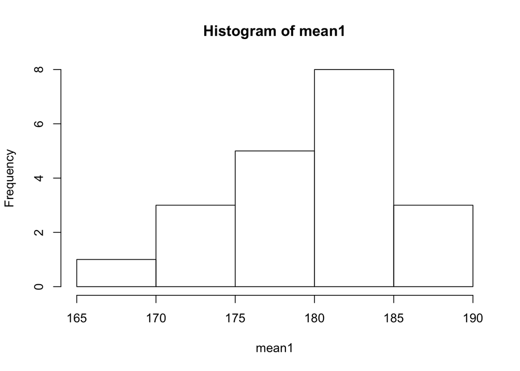

```r
tmp <- rnorm(20*3, 180, 10)
our_samples <- matrix(tmp, ncol=3)

mean1 <- apply(our_samples, 1, mean)

hist(mean1)
```

Sample size can be increased so let’s see what we will get if we work with samples of size 300.

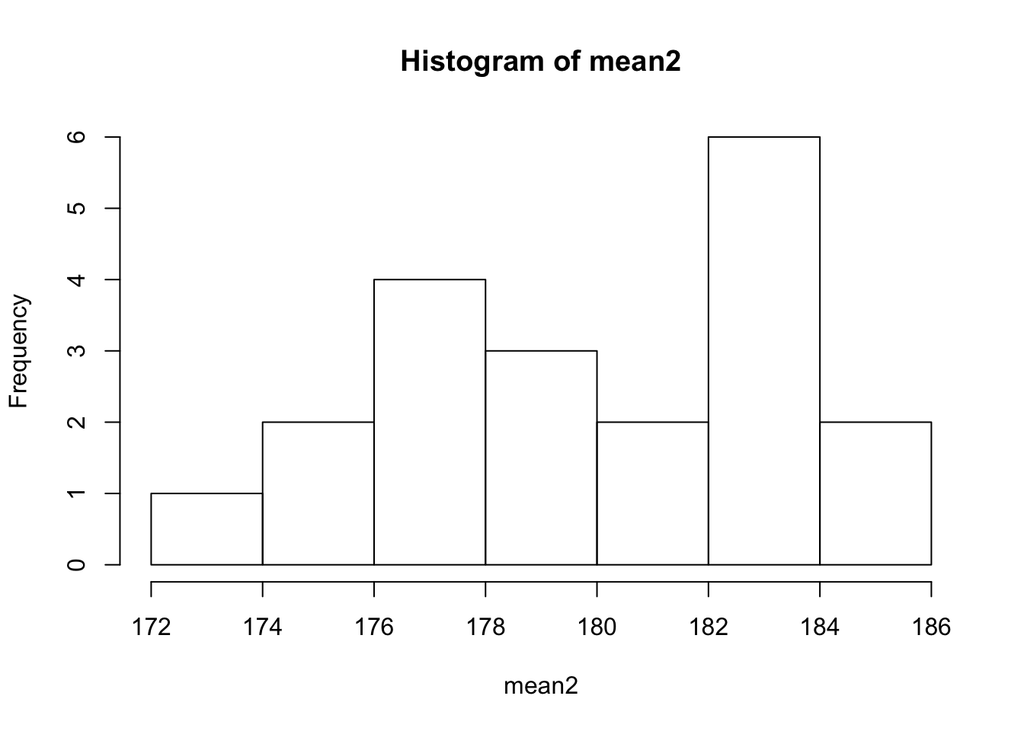

```r
mean2 <- replicate(20, mean(rnorm(300, 180, 100)))

hist(mean2)
```

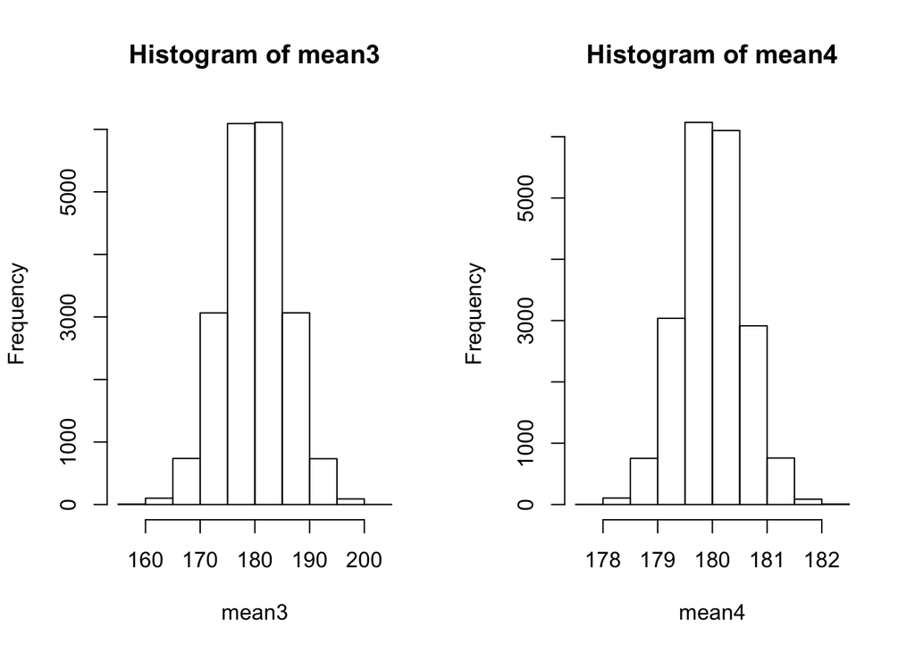

```r
mean3 <- replicate(20000, mean(rnorm(3, 180, 10)))

mean4 <- replicate(20000, mean(rnorm(300, 180, 10)))

par(mfrow=c(1,2))
hist(mean3)
hist(mean4)
```

By increasing the number of simulations we have improved our insight into the distribution behind the sample mean and it seems this distribution could be Normal.

## Confidence Intervals for the Mean (Normal Distribution) - Known Variance

```r
N <- 100

x <- rnorm(N, 180, 10)

alpha <- 0.05
q <- qnorm(alpha/2)

lower_limit <- mean(x) - abs(q) * 10 / sqrt(N)
upper_limit <- mean(x) + abs(q) * 10 / sqrt(N)

print(c(lower_limit, upper_limit))
```

```
## [1] 178.0445 181.9644
```

## Confidence interval (Bernoulli)

We will use the approximation with the normal distribution.

The underlying model will be based on the Bernoulli distribution with the probability of succes equal to 43%.

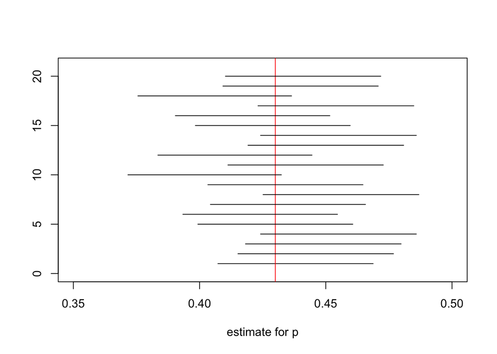

```r
N <- 1000
alpha <- 0.05
ninterval <- 20

q <- qnorm(alpha/2)

x <- rbinom(N, 1, 0.43)

p <- mean(x)

lower_bound <- p - q * sqrt(p*(1-p)) / sqrt(N)
upper_bound <- p + q * sqrt(p*(1-p)) / sqrt(N)

plot(c(lower_bound, upper_bound), c(1,1),
     type = "l",
     xlim = c(0.35, 0.5),
     ylim = c(0, ninterval + 1),
     xlab = "estimate for p",
     ylab = ""
)
abline(v=0.43, col="red")

for( i in 2:ninterval){
  x <- rbinom(N, 1, 0.43)
  p <- mean(x)

  lower_bound <- p - abs(q) * sqrt(p*(1-p)) / sqrt(N)
  upper_bound <- p + abs(q) * sqrt(p*(1-p)) / sqrt(N)

  lines(c(lower_bound, upper_bound), c(i,i))
}
```